# Chap5_1

J.H AHN

2021 12 7

## 5.1 A tidy forecasting workflow

```r
# loading data

head(global_economy)
```

```
## # A tsibble: 6 x 9 [1Y]
## # Key:       Country [1]
##   Country     Code   Year         GDP Growth   CPI Imports Exports Population
##   <fct>       <fct> <dbl>       <dbl>  <dbl> <dbl>   <dbl>   <dbl>      <dbl>
## 1 Afghanistan AFG    1960  537777811.     NA    NA    7.02    4.13    8996351
## 2 Afghanistan AFG    1961  548888896.     NA    NA    8.10    4.45    9166764
## 3 Afghanistan AFG    1962  546666678.     NA    NA    9.35    4.88    9345868
## 4 Afghanistan AFG    1963  751111191.     NA    NA   16.9     9.17    9533954
## 5 Afghanistan AFG    1964  800000044.     NA    NA   18.1     8.89    9731361
## 6 Afghanistan AFG    1965 1006666638.     NA    NA   21.4    11.3     9938414
```

### Data preparation (tidy)

```r
gdppc <-
    global_economy %>%
    mutate(GDP_per_capita = GDP / Population)

gdppc
```

```
## # A tsibble: 15,150 x 10 [1Y]
## # Key:       Country [263]
##    Country     Code   Year         GDP Growth   CPI Imports Exports Population
##    <fct>       <fct> <dbl>       <dbl>  <dbl> <dbl>   <dbl>   <dbl>      <dbl>
##  1 Afghanistan AFG    1960  537777811.     NA    NA    7.02    4.13    8996351
##  2 Afghanistan AFG    1961  548888896.     NA    NA    8.10    4.45    9166764
##  3 Afghanistan AFG    1962  546666678.     NA    NA    9.35    4.88    9345868
##  4 Afghanistan AFG    1963  751111191.     NA    NA   16.9     9.17    9533954
##  5 Afghanistan AFG    1964  800000044.     NA    NA   18.1     8.89    9731361
##  6 Afghanistan AFG    1965 1006666638.     NA    NA   21.4    11.3     9938414
##  7 Afghanistan AFG    1966 1399999967.     NA    NA   18.6     8.57   10152331
##  8 Afghanistan AFG    1967 1673333418.     NA    NA   14.2     6.77   10372630
##  9 Afghanistan AFG    1968 1373333367.     NA    NA   15.2     8.90   10604346
## 10 Afghanistan AFG    1969 1408888922.     NA    NA   15.0    10.1    10854428
## # ... with 15,140 more rows, and 1 more variable: GDP_per_capita <dbl>
```

### Plot the data (visulaise)

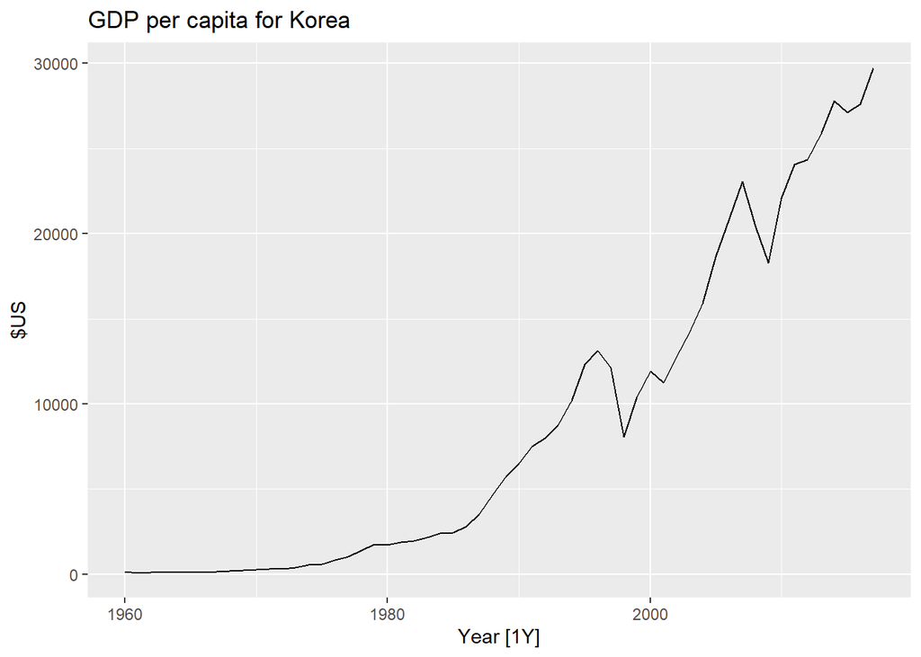

```r
gdppc %>%
    filter(Country == "Korea, Rep.") %>%
    autoplot(GDP_per_capita) +
    labs(y = "$US", title = "GDP per capita for Korea")
```

### Define a model (specify)

`fable` package를 이용하여 모델을 만들 수 있음.  
예를 들어 1인당 GDP에 대한 선형 추세 모델은 아래와 같이 만들 수 있음.

```r
TSLM(GDP_per_capita ~ trend())
```

```
## <TSLM model definition>
```

`fable::TSLM()`은 시계열 데이터를 선형모델(Linear model)로 적합(fit)하기 위한 함수.  
`TSLM(formula)` 형식으로 사용.  
반응변수(Response variable)를 GDP_per_capita로 설정하고, `trend()`함수를 사용하여 모델을 만듦.  
`TSLM()`에서 사용할 수 있는 공통 외인성 회귀변수(Common exogenous regressors)로는 `trend()`, `season()`, `fourier()`가 있음.

- **trend()** : special includes common linear trend regressors in the model.
- **season()** : special includes seasonal dummy variables in the model.
- **fourier()** : special includes seasonal fourier terms in the model.

### Train the model (estimate)

```r
fit <-
    gdppc %>%
    model(trend_model = TSLM(GDP_per_capita ~ trend()))

fit
```

```
## # A mable: 263 x 2
## # Key:     Country [263]
##    Country             trend_model
##    <fct>                   <model>
##  1 Afghanistan              <TSLM>
##  2 Albania                  <TSLM>
##  3 Algeria                  <TSLM>
##  4 American Samoa           <TSLM>
##  5 Andorra                  <TSLM>
##  6 Angola                   <TSLM>
##  7 Antigua and Barbuda      <TSLM>
##  8 Arab World               <TSLM>
##  9 Argentina                <TSLM>
## 10 Armenia                  <TSLM>
## # ... with 253 more rows
```

### Product forecasts (forecast)

적절한 모델을 생성한 후에는 `forecast()`함수를 이용하여 예측결과를 생성.  
예측하고자 하는 값에 따라 다음 10개 관측값을 예측하고 싶다면 h = 10, 다음 2년치를 예측하고 싶다면 h = “2 years”로 입력하면 된다.

다른 상황에서는 예측할 (미래의) 데이터를 제공하면 exogenous regressors를 사용하여 예측할 때 사용된다.

```r
fit %>%
    forecast(h = "3 years")
```

```
## # A fable: 789 x 5 [1Y]
## # Key:     Country, .model [263]
##    Country        .model       Year   GDP_per_capita  .mean
##    <fct>          <chr>       <dbl>           <dist>  <dbl>
##  1 Afghanistan    trend_model  2018     N(526, 9653)   526.
##  2 Afghanistan    trend_model  2019     N(534, 9689)   534.
##  3 Afghanistan    trend_model  2020     N(542, 9727)   542.
##  4 Albania        trend_model  2018  N(4716, 476419)  4716.
##  5 Albania        trend_model  2019  N(4867, 481086)  4867.
##  6 Albania        trend_model  2020  N(5018, 486012)  5018.
##  7 Algeria        trend_model  2018  N(4410, 643094)  4410.
##  8 Algeria        trend_model  2019  N(4489, 645311)  4489.
##  9 Algeria        trend_model  2020  N(4568, 647602)  4568.
## 10 American Samoa trend_model  2018 N(12491, 652926) 12491.
## # ... with 779 more rows
```

계산 결과에서 `GDP_per_capita` 열에는 예측 분포값이 들어 있고 `.mean` 열에는 예측값들의 평균값이 들어있다.

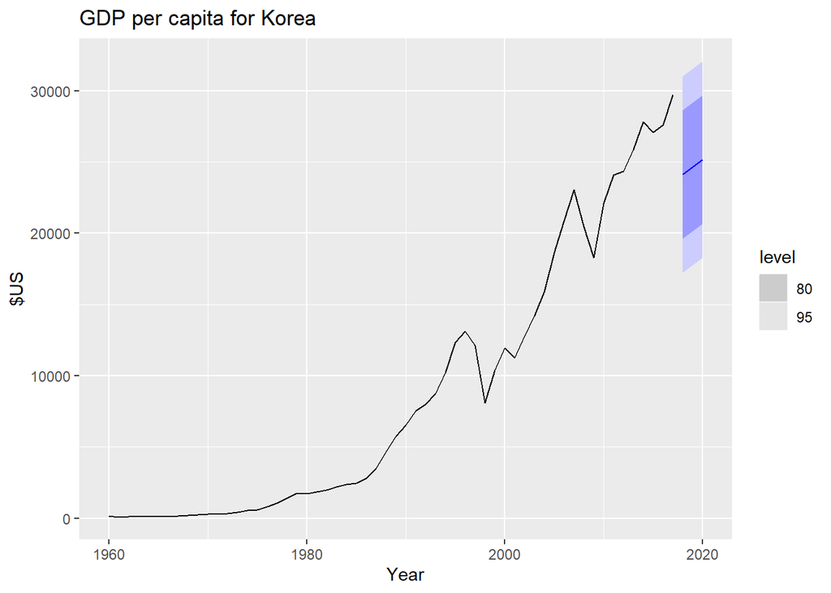

```r
fit %>%
    forecast(h = "3 years") %>%
    filter(Country == "Korea, Rep.") %>%
    autoplot(gdppc) +
    labs(y = "$US", title = "GDP per capita for Korea")
```